# Practical Machine Learning Assignment

# Summary

The current project intends to build a predictive model able to categorize the barbell lift class, notably from the accelerometers readings.

## Background

Using devices such as Jawbone Up, Nike FuelBand, and Fitbit it is now possible to collect a large amount of data about personal activity relatively inexpensively. These type of devices are part of the quantified self movement, a group of enthusiasts who take measurements about themselves regularly to improve their health, to find patterns in their behavior, or because they are tech geeks. One thing that people regularly do is quantify how much of a particular activity they do, but they rarely quantify how well they do it. In this project, the goal is to use data from accelerometers on the belt, forearm, arm, and dumbell of 6 participants. They were asked to perform barbell lifts correctly and incorrectly in 5 different ways. More information is available from the website here: http://groupware.les.inf.puc-rio.br/har (see the section on the Weight Lifting Exercise Dataset).

- Borrowed from the Practical Machine Learning assignment excerpt.

## Data Used

The training data for this project are available here:

https://d396qusza40orc.cloudfront.net/predmachlearn/pml-training.csv

The test data are available here:

https://d396qusza40orc.cloudfront.net/predmachlearn/pml-testing.csv

# Analysis

To build the predictive models, the **caret** package and some of its dependencies will be used.

```r
#Loading the packages necessary to the analysis
require(caret)
require(randomForest)
require(kernlab)
```

## Getting and Cleaning the Data

```r
# Verifies if the testing dataset is present in the folder previously specified, otherwise downloads it.
if (file.exists("pml-testing.csv")==FALSE){
        download.file("https://d396qusza40orc.cloudfront.net/predmachlearn/pml-testing.csv", destfile="pml-testing.csv", method="curl")
}

# Verifies if the training dataset is present in the folder previously specified, otherwise downloads it.
if (file.exists("pml-training.csv")==FALSE){
        download.file("https://d396qusza40orc.cloudfront.net/predmachlearn/pml-training.csv", destfile="pml-training.csv", method="curl")
}

#loading the testing set data containing the 20 samples to predict
testing <- read.csv("pml-testing.csv",na.strings = c("NA","","<NA>"))
#loading the training set data on which to build the model on.
training <- read.csv("pml-training.csv",na.strings = c("NA","","<NA>"))
```

Now that the data is in R, we will give it a quick look.

```r
#Proportion of cells that are NA
sum(is.na(training))/(dim(training)[1]*dim(training)[2])
```

```
## [1] 0.6120681
```

```r
#proprotion of samples with data in every column/variable
sum(complete.cases(training))/nrow(training)
```

```
## [1] 0.02069106
```

```r
#finding all the NA cells
AllNAs <- lapply(training,is.na)

#Counting the number of NA cells per column
namesSum <- unlist(lapply(AllNAs,sum))
summary(namesSum)
```

```
##    Min. 1st Qu.  Median    Mean 3rd Qu.    Max.
##       0       0   19220   12010   19220   19220
```

The number of cells containing NAs is non-neglectable and thus impacts the observations where all variables have been measured. As the summary shows, the columns containing NAs looks heavily skewed. There are 100 columns with 98 percent of its samples being NAs. Their removal will not impact the quality of the models and will reduce computing time significantly.

```r
#removing ID variables stored under X
testing$X <- NULL
training$X <- NULL

#removing the problem_id from the test set, as they are of no use.
testing$problem_id <- NULL

#removing the columns whit more than 1000 NAs in the observations.
remove <- names(namesSum[(namesSum>1000)==T]) #to be removed
training2 <- training[,!(names(training) %in% remove)] #removing the columns from training
testing2 <- testing[,!(names(testing) %in% remove)] #removing the columns from testing
```

## Cross Validation

```r
#For reproduceability purposes
set.seed(3452)

#splitting the training dataset with a 60/40 ratio
inTrain <- createDataPartition(training2$classe,p=.4,list=F)
#building the training dataset for the model
train2 <- training2[inTrain,]
#building the dataset on which the model will be tested
test2 <- training2[-inTrain,]

#freeing up some memory
rm(inTrain, training, testing, training2)
```

Before delving into the prediction of the **testing** dataset, the model must first be built and tested on the **training** dataset. To do so, some cross validation will be executed by splitting the **training** dataset into two subsets. This split will randomly allocate 40% of the observations (7850 obs.) for the models to be trained on, and 60% to validate the accuracy of the model (11772 obs.). Experiments with this dataset have shown that this number of observations is sufficient to obtain performant models.

On top of that, **caret** uses 25 reps bootstrapping by default, which parameters will be maintained.

## Model Building

After experimenting with various machine learning methods, two have been retained for comparison in order to spare some computation time. As mentionned, both models have been built on the refined subset of the **training** dataset, and using default parameters from the **caret** package.

The two methods retained are linear SVM, as recommended by the [scikit-learn.org flow chart](http://scikit-learn.org/stable/tutorial/machine_learning_map/index.html), and a random forest, which has shown its adaptability throughout the lectures.

```r
#Random forest algorithm
foretAlea <- train(classe ~ .,method="rf",train2)

#Linear SVM algorithm
SVMl <- train(classe ~ .,method="svmLinear",train2)


#Out of Sample errors from the models
OoSErf <- 1 - foretAlea$results$Accuracy[3]
OoSEsvm <- 1 - SVMl$results$Accuracy
```

### Out of Sample Error expectations

The out of sample error rate is not expected to go up from the ones provided by the two models. Therefore, the following error rates are exepected:

- Linear SVM : 0.0988772
- Random Forest: 0.0070413

## Model Selection

### Random Forest

```r
#final validation random forest
rfCFM <- confusionMatrix(predict(foretAlea,test2),test2$classe)
rfCFM
```

```
## Confusion Matrix and Statistics
##
##           Reference
## Prediction    A    B    C    D    E
##          A 3347    1    0    0    0
##          B    1 2277   14    0    0
##          C    0    0 2033   10    0
##          D    0    0    6 1914    2
##          E    0    0    0    5 2162
##
## Overall Statistics
##
##                Accuracy : 0.9967
##                  95% CI : (0.9955, 0.9976)
##     No Information Rate : 0.2844
##     P-Value [Acc > NIR] : < 2.2e-16
##
##                   Kappa : 0.9958
##  Mcnemar's Test P-Value : NA
##
## Statistics by Class:
##
##                      Class: A Class: B Class: C Class: D Class: E
## Sensitivity            0.9997   0.9996   0.9903   0.9922   0.9991
## Specificity            0.9999   0.9984   0.9990   0.9992   0.9995
## Pos Pred Value         0.9997   0.9935   0.9951   0.9958   0.9977
## Neg Pred Value         0.9999   0.9999   0.9979   0.9985   0.9998
## Prevalence             0.2844   0.1935   0.1744   0.1639   0.1838
## Detection Rate         0.2843   0.1934   0.1727   0.1626   0.1837
## Detection Prevalence   0.2844   0.1947   0.1735   0.1633   0.1841
## Balanced Accuracy      0.9998   0.9990   0.9946   0.9957   0.9993
```

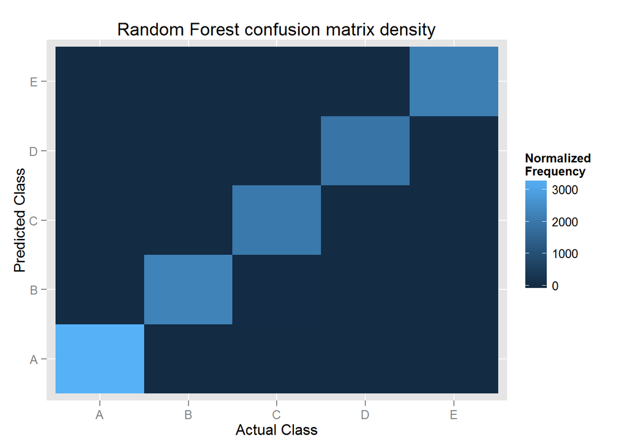

```r
drfCFM <- data.frame(rfCFM$table)

plotRF <- ggplot(drfCFM)
plotRF + geom_tile(aes(x=drfCFM$Reference, y=drfCFM$Prediction, fill=drfCFM$Freq)) + scale_x_discrete(name="Actual Class") +
  scale_y_discrete(name="Predicted Class") + scale_fill_gradient() +
  labs(fill="Normalized\nFrequency", title="Random Forest confusion matrix density")
```

### Linear SVM

```r
#final validation linear SVM
svmCFM <- confusionMatrix(predict(SVMl,test2),test2$classe)
svmCFM
```

```
## Confusion Matrix and Statistics
##
##           Reference
## Prediction    A    B    C    D    E
##          A 3276  274   12    5    1
##          B   60 1857  159   16    0
##          C   12  147 1863  143   14
##          D    0    0   18 1644  134
##          E    0    0    1  121 2015
##
## Overall Statistics
##
##                Accuracy : 0.9051
##                  95% CI : (0.8997, 0.9103)
##     No Information Rate : 0.2844
##     P-Value [Acc > NIR] : < 2.2e-16
##
##                   Kappa : 0.8797
##  Mcnemar's Test P-Value : NA
##
## Statistics by Class:
##
##                      Class: A Class: B Class: C Class: D Class: E
## Sensitivity            0.9785   0.8152   0.9075   0.8523   0.9311
## Specificity            0.9653   0.9752   0.9675   0.9846   0.9873
## Pos Pred Value         0.9182   0.8877   0.8550   0.9154   0.9429
## Neg Pred Value         0.9912   0.9565   0.9802   0.9714   0.9845
## Prevalence             0.2844   0.1935   0.1744   0.1639   0.1838
## Detection Rate         0.2783   0.1577   0.1583   0.1397   0.1712
## Detection Prevalence   0.3031   0.1777   0.1851   0.1526   0.1815
## Balanced Accuracy      0.9719   0.8952   0.9375   0.9184   0.9592
```

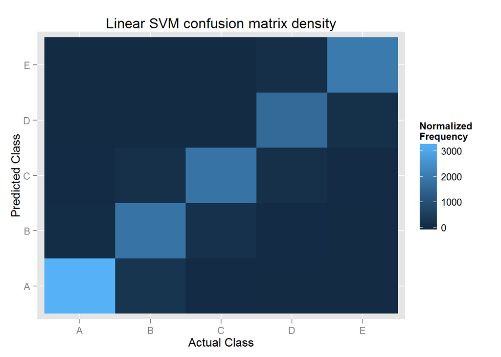

```r
dsvmCFM <- data.frame(svmCFM$table)

plotSVM <- ggplot(dsvmCFM)
plotSVM + geom_tile(aes(x=dsvmCFM$Reference, y=dsvmCFM$Prediction, fill=dsvmCFM$Freq)) + scale_x_discrete(name="Actual Class") +
  scale_y_discrete(name="Predicted Class") + scale_fill_gradient() +
  labs(fill="Normalized\nFrequency",title="Linear SVM confusion matrix density")
```

### Selection Rationale

Given the preceding results and some experimentation with various machine learning algorithms, the random forest proved to be the most efficient. With reasonable computing time (~ 45 minutes) and near perfect accuracy (0.9966871), it outclassed the linear SVM’s accuracy (0.9051138), and all others previously tried, with the notable exception of the stochastic grandient boosting algorithm (“gbm”) which matched its accuracy. These results prove to be in line with the expected out of sample errors previously mentionned, for both the random forest (0.0033129) and the SVM (0.0948862).

Despite the considerably lower processing time of the linear SVM, the accuracy compromise compared to the random forest is deemed too large to retain it. Waiting a few more minutes for near perfect accuracy may prove well worth it when meeting new data.

## Final Predictions

```r
#prediciting the answers with the random forest
predict(foretAlea,testing2)
```

```
##  [1] B A B A A E D B A A B C B A E E A B B B
## Levels: A B C D E
```

```r
#prediciting the answers with the SVM
predict(SVMl,testing2)
```

```
##  [1] B A B A A E D B A A B C B A E E A B B B
## Levels: A B C D E
```

Both make the same predictions on the 20 observations from the **testing** dataset.